# 1 Install and load required packages

## 1.1 Install Packages

```r
# To install packcages uncomment the following line

#install.packages(c("ggplot2","dpylr", "ggridges", "raincloudplots", "cowplot", "data.table", "ggrepel", "sjPlot", "bayesplot", "reshape2", "purrr", "tidyr", "brms", "emmeans", "modelr", "plyr", "pacthwork", "spatstat", "ggdist", "ggpubr", "bayesplot", "RandomFieldsUtils", "RandomFields"))

#library(devtools)
#install_github ("cran/RandomFields")
```

## 1.2 Load required Packages

After installation is performed, we load the required libraries a new R-session is started.

```r
library(ggplot2)
library(dplyr)
library(reshape2)
library(purrr)
library(tidyr)
library(plyr)
library(spatstat)
library(data.table)
library(cowplot)
library(bayesplot)
library(MASS)
library(ggpubr)
library(jtools)
```

# 2 Analysis of neurological score

We fit an ordinal logistic regression model using the “polr” function from the MASS package (*1*) to analyze the neurological score at 24 hours and 3 days following injury. We use ‘score’ as the outcome variable, and ‘Time’ and ‘Group’ as predictor variables.

```r
# We load the data set
NeurologicalScore <- read.csv(file = 'NSS Dkk1-stroke.csv', header = TRUE)

# We specify the factor levels for Gropus
NeurologicalScore$Group <- factor(NeurologicalScore$Group, levels = c("DKK1/OFF", "WT/DOX", "DKK1/ON"))

# We convert the score to factor (ordered)
NeurologicalScore$Score <- as.factor(NeurologicalScore$Score)

# Fit the model
NeurologicalScore_Mdl1 <- polr(as.ordered(Score) ~ Time * Group, data = NeurologicalScore, Hess = TRUE)

# Print a summary of the model
summary(NeurologicalScore_Mdl1)
```

```
Call:
polr(formula = as.ordered(Score) ~ Time * Group, data = NeurologicalScore,
    Hess = TRUE)

Coefficients:
                    Value Std. Error t value
Time              -0.5307     0.5999 -0.8848
GroupWT/DOX        0.9015     1.6117  0.5593
GroupDKK1/ON       2.7599     1.8527  1.4896
Time:GroupWT/DOX  -0.6677     0.7524 -0.8875
Time:GroupDKK1/ON  0.5990     0.8142  0.7357

Intercepts:
      Value   Std. Error t value
0|0.5 -5.1593  1.6966    -3.0410
0.5|1 -3.2905  1.4191    -2.3188
1|1.5 -1.0551  1.2773    -0.8261
1.5|2 -0.4967  1.2591    -0.3944
2|2.5  1.3754  1.3208     1.0414
2.5|3  2.6779  1.4220     1.8833
3|3.5  5.3458  1.7428     3.0674

Residual Deviance: 113.562
AIC: 137.562
```

## 2.1 Plot the neurological score (line plot)

Next, we use the `predict` function to generate predictions in the probability scale for each score based on the fitted model.

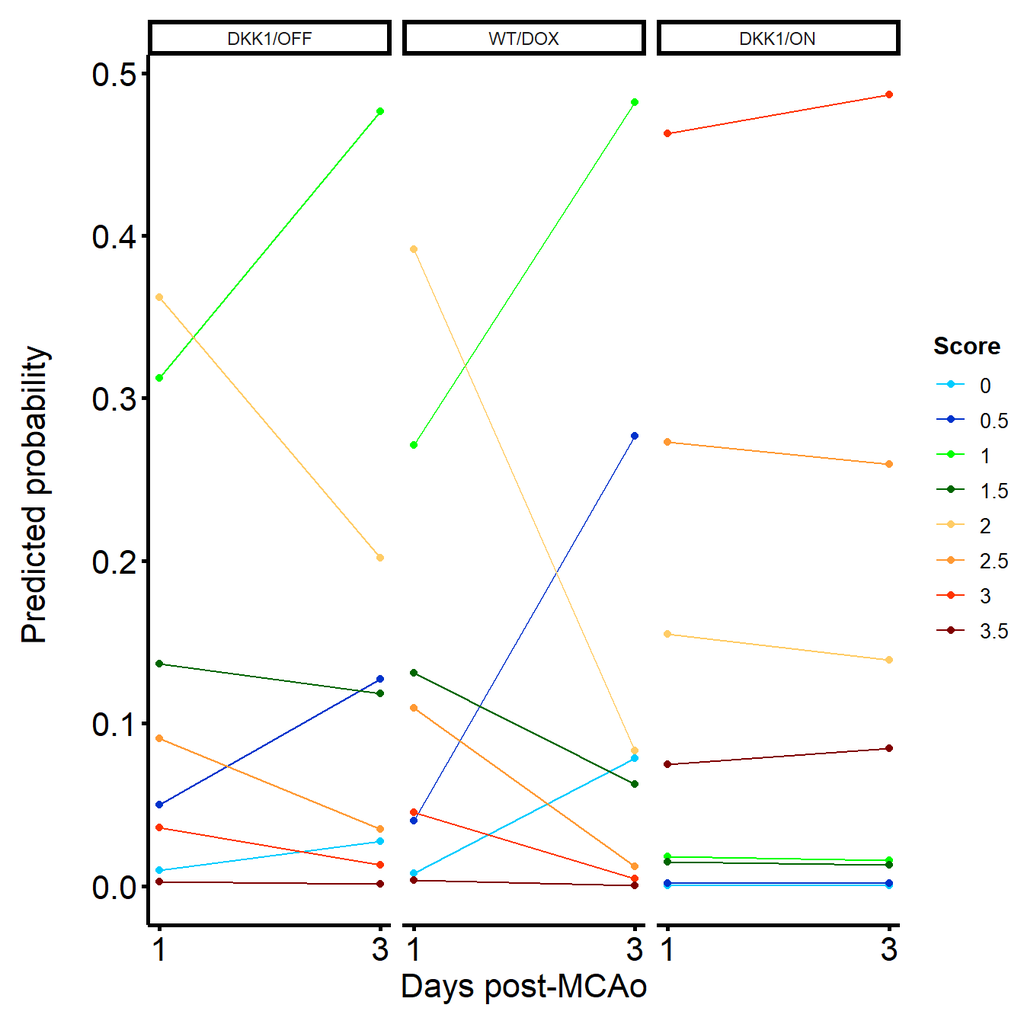

```r
# Create a new data frame for predictions
newdata <- expand.grid(Time = unique(NeurologicalScore$Time),
                       Group = levels(NeurologicalScore$Group))


# Generate predictions
predictions <- predict(NeurologicalScore_Mdl1, newdata = newdata, type = "probs")

# Rename columns of predictions to ensure they're unique
colnames(predictions) <- paste0("Score_", colnames(predictions))

# Add the predictions to the new data frame
newdata <- cbind(newdata, predictions)

# Convert to long format for plotting
predictions_long <- tidyr::pivot_longer(newdata, cols = starts_with("Score_"),
                                        names_to = "Score", values_to = "Probability")

# Remove the "Score_" prefix from the Score variable
predictions_long$Score <- gsub("Score_", "", predictions_long$Score)

# Plot
NeurologicalScore_Fig <- ggplot(predictions_long, aes(x = Time, y = Probability, color = Score)) +
  geom_line() +
  geom_point() +
  labs(x = "Days post-MCAo", y = "Predicted probability \n", color = "Score") +
  scale_x_continuous(
  breaks =c(1, 3)) +

  scale_color_manual(values = c("#00ccff", "#0033cc", "#00ff00", "#006600", "#ffcc66",  "#ff9933", "#ff3300", "#800000")) +

  facet_wrap(~ Group) +
  theme_classic() +


    theme(
      plot.title = element_text(size=18, hjust = 0.5, face="bold"),
      plot.subtitle = element_text(size = 12, color = "black"),
      plot.caption = element_text(size = 12, color = "black"),
      axis.line = element_line(colour = "black", size = 1, linetype = "solid"),
      axis.ticks.length=unit(3,"pt"),

      axis.title.x = element_text(colour = "black", size = 16),
      axis.text.x = element_text(colour = "black", size = 16, angle = 0, hjust = 0.5),
      axis.ticks.x = element_line(colour = "black", size = 1),

      axis.title.y = element_text(colour = "black", size = 16),
      axis.text.y = element_text(colour = "black", size = 16),
      axis.ticks.y = element_line(colour = "black", size = 1),

      legend.position="right",
      legend.direction="vertical",
      legend.title = element_text(colour="black", face="bold", size=12),
      legend.text = element_text(colour="black", size=10),

      strip.background = element_rect(color="black",
                                      size=2,
                                      linetype="solid"),


      plot.margin = margin(t = 10,  # Top margin
                             r = 2,  # Right margin
                             b = 10,  # Bottom margin
                             l = 10) # Left margin
      )

ggsave(
  plot     = NeurologicalScore_Fig,
  filename = "Plots/NeurologicalScore_Fig.png",
  width    = 15,
  height   = 13,
  units    = "cm")

NeurologicalScore_Fig
```

## 2.2 Plot the neurological score (Stacked bar)

We used the same data set to created a stacked bar plot accounting for the probability scale.

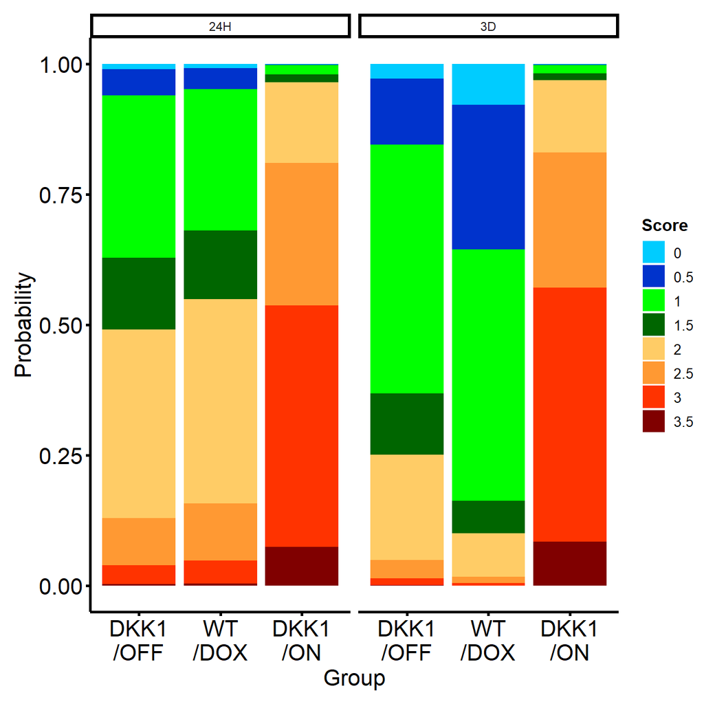

```r
predictions_long$Time2 <- as.factor(predictions_long$Time)

predictions_long$Time2 <- revalue(predictions_long$Time2, c("1" = "24H", "3" = "3D"))

NeurologicalScore_Bar <- ggplot(predictions_long, aes(fill=Score, y=Probability, x=Group)) +

    geom_bar(position="fill", stat="identity") +

  scale_fill_manual(values = c("#00ccff", "#0033cc", "#00ff00", "#006600", "#ffcc66",  "#ff9933", "#ff3300", "#800000")) +

  scale_x_discrete (labels = c("DKK1\n/OFF", "WT\n/DOX", "DKK1\n/ON")) +

   theme_classic() +

    theme(
      plot.title = element_text(size=18, hjust = 0.5, face="bold"),
      plot.subtitle = element_text(size = 12, color = "black"),
      plot.caption = element_text(size = 12, color = "black"),
      axis.line = element_line(colour = "black", size = 1, linetype = "solid"),
      axis.ticks.length=unit(3,"pt"),

      axis.title.x = element_text(colour = "black", size = 16),
      axis.text.x = element_text(colour = "black", size = 16, angle = 0, hjust = 0.5),
      axis.ticks.x = element_line(colour = "black", size = 1),

      axis.title.y = element_text(colour = "black", size = 16),
      axis.text.y = element_text(colour = "black", size = 16),
      axis.ticks.y = element_line(colour = "black", size = 1),

      legend.position="right",
      legend.direction="vertical",
      legend.title = element_text(colour="black", face="bold", size=12),
      legend.text = element_text(colour="black", size=10),

       strip.background = element_rect(color="black",
                                      size=2,
                                      linetype="solid"),

      plot.margin = margin(t = 10,  # Top margin
                             r = 2,  # Right margin
                             b = 10,  # Bottom margin
                             l = 10) # Left margin

    ) +

  facet_grid(~ Time2)

ggsave(
  plot     = NeurologicalScore_Bar,
  filename = "Plots/NeurologicalScore_Bar.png",
  width    = 15,
  height   = 13,
  units    = "cm")


NeurologicalScore_Bar
```

# 3 Analysis of horizontal bar test

We fit an ordinal logistic regression model to analize using the horizontal bar test at 24 hours and 3 days following injury. Please note that the scores (time on the rod) are represented as ratios to the baseline value. We preformed a quartile division of the score (“0-0.25”, “0.25-0.50”, “0.50-0.75”, “0.75-1”) as the outcome variable, and ‘Time’ and ‘Group’ as predictor variables.

```r
# We load the data set
HorizontalBar <- read.csv(file = 'DataTables/HorizontalBar_V2.csv', header = TRUE)

# We specify the factor levels for Groups
HorizontalBar$Group <- factor(HorizontalBar$Group, levels = c("DKK1/OFF", "WT/DOX", "DKK1/ON"))

# Define the range boundaries
range <- c(0, 0.25, 0.50, 0.75, 1)
ordinal_labels <- c("0-0.25", "0.25-0.50", "0.50-0.75", "0.75-1")

convert_to_ordinal <- function(Score) {
  category <- cut(Score, range, labels = ordinal_labels, include.lowest = TRUE)
  return(as.character(category))
}

# Apply the conversion function to the Time column in the data set
HorizontalBar$Range <- convert_to_ordinal(HorizontalBar$Score)

# We convert the score to factor (ordered)
HorizontalBar$Range <- factor(HorizontalBar$Range, levels = c("0-0.25", "0.25-0.50", "0.50-0.75", "0.75-1"))

# Fit the model
HorizontalBar_Mdl1 <- polr(as.ordered(Range) ~ Time * Group, data = HorizontalBar, Hess = TRUE)

# Print a summary of the model
summary(HorizontalBar_Mdl1)
```

```
Call:
polr(formula = as.ordered(Range) ~ Time * Group, data = HorizontalBar,
    Hess = TRUE)

Coefficients:
                     Value Std. Error  t value
Time               16.6337     0.4842  34.3498
GroupWT/DOX        -0.4637     1.1967  -0.3875
GroupDKK1/ON       -1.0007     1.1168  -0.8961
Time:GroupWT/DOX  -16.1643     0.7904 -20.4509
Time:GroupDKK1/ON -16.3812     0.7389 -22.1695

Intercepts:
                    Value    Std. Error t value
0-0.25|0.25-0.50     -1.7552   0.9493    -1.8489
0.25-0.50|0.50-0.75  -0.9506   0.9058    -1.0495
0.50-0.75|0.75-1     -0.2749   0.8975    -0.3063

Residual Deviance: 78.08642
AIC: 94.08642
(7 observations deleted due to missingness)
```

## 3.1 Plot the horizontal bar score (line plot)

Next, we use the `predict` function to generate predictions in the probability scale for each score based on the fitted model.

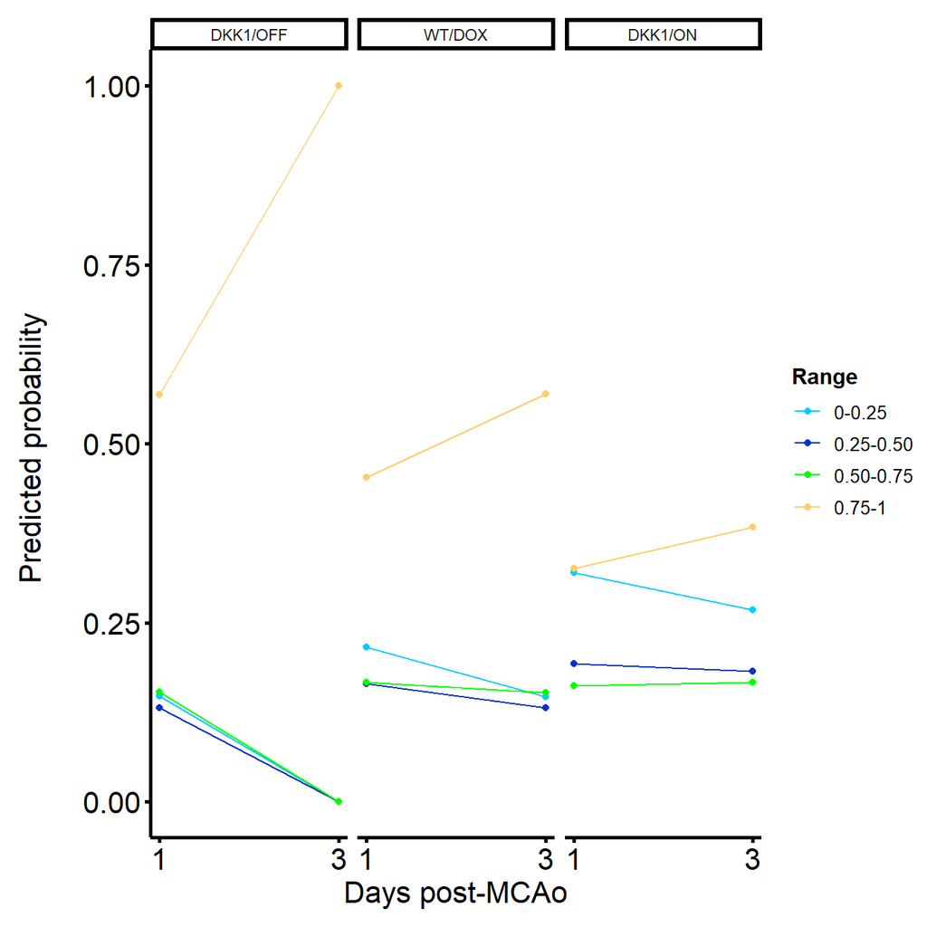

```r
# Create a new data frame for predictions
newdata <- expand.grid(Time = unique(HorizontalBar$Time),
                       Group = levels(HorizontalBar$Group))


# Generate predictions
predictions <- predict(HorizontalBar_Mdl1, newdata = newdata, type = "probs")

# Rename columns of predictions to ensure they're unique
colnames(predictions) <- paste0("Range_", colnames(predictions))

# Add the predictions to the new data frame
newdata <- cbind(newdata, predictions)

# Convert to long format for plotting
predictions_long <- tidyr::pivot_longer(newdata, cols = starts_with("Range_"),
                                        names_to = "Range", values_to = "Probability")

# Remove the "Score_" prefix from the Score variable
predictions_long$Score <- gsub("Range_", "", predictions_long$Range)

# Plot
HorizontalBar_Fig <- ggplot(predictions_long, aes(x = Time, y = Probability, color = Score)) +
  geom_line() +
  geom_point() +
  labs(x = "Days post-MCAo", y = "Predicted probability \n", color = "Range") +
  scale_x_continuous(
  breaks =c(0, 1),
  labels = c ("1", "3")) +

  scale_color_manual(values = c("#00ccff", "#0033cc", "#00ff00", "#ffcc66",  "#ff3300", "#800000")) +

  facet_wrap(~ Group) +
  theme_classic() +


    theme(
      plot.title = element_text(size=18, hjust = 0.5, face="bold"),
      plot.subtitle = element_text(size = 12, color = "black"),
      plot.caption = element_text(size = 12, color = "black"),
      axis.line = element_line(colour = "black", size = 1, linetype = "solid"),
      axis.ticks.length=unit(3,"pt"),

      axis.title.x = element_text(colour = "black", size = 16),
      axis.text.x = element_text(colour = "black", size = 16, angle = 0, hjust = 0.5),
      axis.ticks.x = element_line(colour = "black", size = 1),

      axis.title.y = element_text(colour = "black", size = 16),
      axis.text.y = element_text(colour = "black", size = 16),
      axis.ticks.y = element_line(colour = "black", size = 1),

      legend.position="right",
      legend.direction="vertical",
      legend.title = element_text(colour="black", face="bold", size=12),
      legend.text = element_text(colour="black", size=10),

      strip.background = element_rect(color="black",
                                      size=2,
                                      linetype="solid"),


      plot.margin = margin(t = 10,  # Top margin
                             r = 2,  # Right margin
                             b = 10,  # Bottom margin
                             l = 10) # Left margin
      )

ggsave(
  plot     = HorizontalBar_Fig,
  filename = "Plots/HorizontalBar_Fig.png",
  width    = 15,
  height   = 13,
  units    = "cm")

HorizontalBar_Fig
```

# 4 References

1.

W. N. Venables, B. D. Ripley, Modern applied statistics with s (2002) (available at https://www.stats.ox.ac.uk/pub/MASS4/).